# US GNP AR2

Dawu Liu

**(b) Use the MLE to fit an AR(2) model.**

**1. Read in the data**

**(a)** Plot the data.

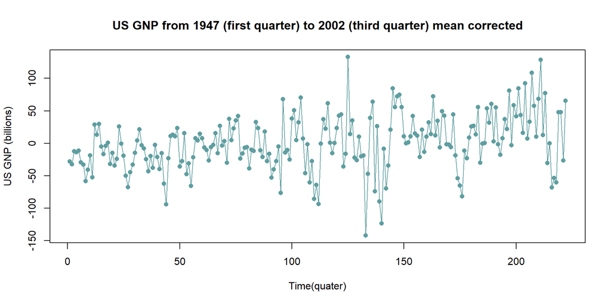

**(c)** Plot the sample acf/pacf.

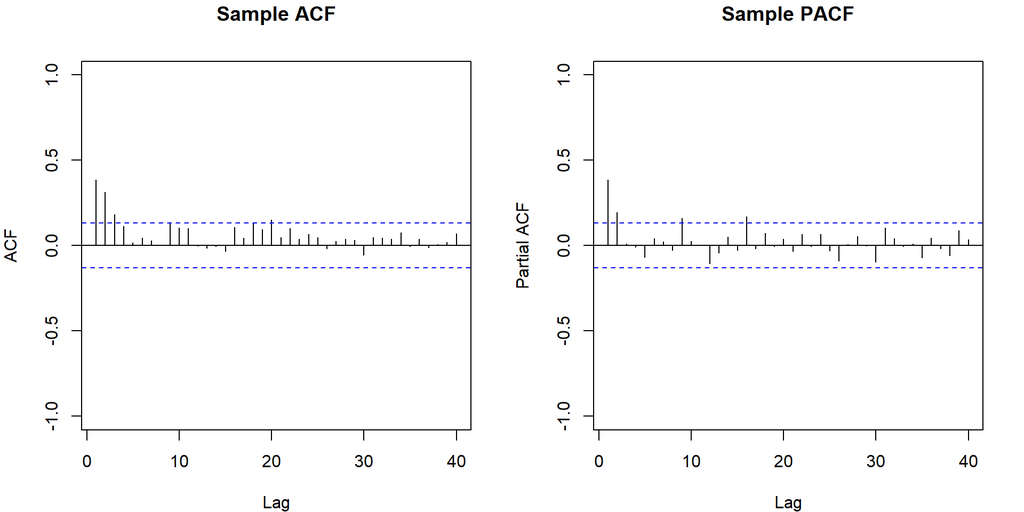

**(d)** Use the plot to make observations about possible orders of dependency.

We can see the acf decays after lag > 0 in the sample ACF plot. The partial acf cuts off after lag = 2 in the sample PACF plot. After lag =2 , only 2 pacf are beyond the 95% CI. This might indicate the order of dependency is p=2, AR(2).

**2. Estimate the parameters in the specified model using the specified method.**

```
##
## Call:
## arima(x = y, order = c(2, 0, 0), include.mean = FALSE, method = "ML")
##
## Coefficients:
##          ar1     ar2
##       0.3136  0.1930
## s.e.  0.0662  0.0663
##
## sigma^2 estimated as 1457:  log likelihood = -1123.67,  aic = 2251.34
```

**(a)** Give the estimated coefficients.

The estimated coefficients are: $\hat\phi_1 = 0.3136$, $\hat\phi_2 = 0.1930$, $\hat\sigma^2 = 1457.093$

**(b)** Give the value of the AIC or AICC.

The AIC value is 2251.34

**(c)** Plot the model and sample acf/pacf.

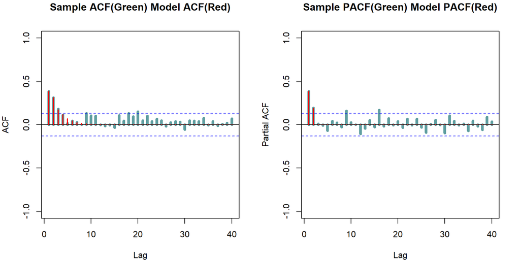

**(d)** Use the plot from (c) to assess the quality of the model fit.

In (c), the model fits the sample very well in both acf/pacf graphs. Especially the at lag = 1,2,3,4 for ACF and lag = 1,2 for PACF. The model captures all the significance of the sample acf/pacf at the first a few lags. The model is a good fit for the sample.

**3. Analyze the standardized residuals.**

**(a)** Plot the standardized residuals.

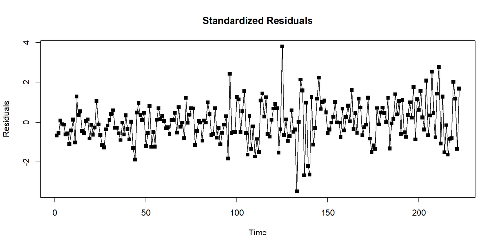

**(b)** Plot the sample acf/pacf for the standardized residuals.

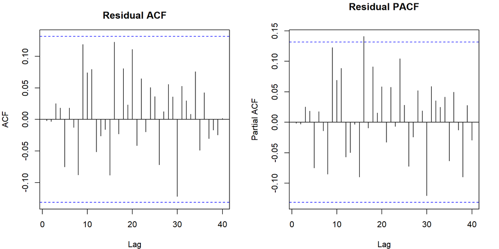

**(c)** Assess the plots for the hypothesis that the residuals are iid.

There is no pattern in the residuals plot. All the residuals acf are within the 95% CI for the acf plot, and only one residual pacf is beyond the 95% CI for the pacf plot at lag > 0. The plots support the hypothesis that residuals being iid.

**(d)** Evaluate the Ljung-Box and McLeod-Li statistics and indicate if they support rejection of the iid hypothesis.

```r
#Ljung-Box test
Box.test(ar2resid, lag = 20, type = "Ljung", fitdf = 0)$p.value
```

```
## [1] 0.413954
```

```r
#McLeod-Li test
Box.test(ar2resid^2, lag = 20, type = "Ljung", fitdf = 0)$p.value
```

```
## [1] 8.019364e-08
```

With lag = 20, the p-values for Ljung-Box and McLeod-Li statistical tests are 0.413954 and 8.019e-08 respectively. LB test fails to reject the iid hypothesis at level 0.05, and ML test supports the rejection of the iid hypothesis at level 0.05.

**(e)** Give a final assessment on the validity of the iid hypothesis.

The next method starts next page.

```r
knitr::opts_chunk$set(echo=FALSE, warning=FALSE, message=FALSE)
library(itsmr)
library(TSA)
data = read.delim("E:/2021 Fall/STAT 485/data/gnp-47-02D.txt", header = FALSE)
y = data$V1 - mean(data$V1)
# 1 (a)
plot(y, type="o", pch=16, col="cadetblue", xlab="Time(quater)", ylab="US GNP (billions)",
     main="US GNP from 1947 (first quarter) to 2002 (third quarter) mean corrected")
# 1 (c)
par(mar=c(4,4,3,2), mfrow=c(1,2))
acf.sample = acf(y, lag.max = 40, plot = FALSE)
plot(acf.sample, ylim=c(-1,1), main="Sample ACF")
pacf.sample = pacf(y, lag.max = 40, plot = FALSE)
plot(pacf.sample, ylim=c(-1,1), main="Sample PACF")
# 2 (a) (b)
ar2 = arima(y, order = c(2,0,0), method = "ML", include.mean = FALSE)
ar2
# 2 (c)
ar2model.acf = ARMAacf(ar=c(ar2$coef[1], ar2$coef[2]), lag.max = 40, pacf = FALSE)
ar2model.pacf = ARMAacf(ar=c(ar2$coef[1],ar2$coef[2]), lag.max = 40, pacf = TRUE)

par(mar=c(4,4,3,2), mfrow=c(1,2))

ar2acf.sample = acf(y, lag.max = 40, plot = FALSE)
plot(ar2acf.sample, ylim=c(-1,1), lwd = 5, col="cadetblue", main="Sample ACF(Green) Model ACF(Red)")
points(ar2model.acf[-1], col="red", type="h", lwd = 2)

ar2pacf.sample = pacf(y, lag.max = 40, plot = FALSE)
plot(ar2pacf.sample, ylim=c(-1,1), lwd = 5, col="cadetblue", main="Sample PACF(Green) Model PACF(Red)")
points(ar2model.pacf, col="red", type="h", lwd = 2)
# 3 (a)
ar2resid = rstandard(ar2)
plot(ar2resid, type="o", pch=15, xlab="Time", ylab="Residuals", main="Standardized Residuals")
# 3 (b)
par(mar=c(4,4,3,2), mfrow=c(1,2))
ar2acf.resid = acf(ar2resid, lag.max = 40, plot = TRUE, main="Residual ACF")
ar2pacf.resid = pacf(ar2resid, lag.max = 40, plot = TRUE, main="Residual PACF")
#Ljung-Box test
Box.test(ar2resid, lag = 20, type = "Ljung", fitdf = 0)$p.value
#McLeod-Li test
Box.test(ar2resid^2, lag = 20, type = "Ljung", fitdf = 0)$p.value
```